# Classification methodology of resistance and tolerance to virus infection in sweetpotato

Kreuze et al.

2023-05-18

## Introduction

Virus infections represent one of the most critical production constraints for sweet potato (*Ipomoea batatas* L.) worldwide. Therefore, increasing virus resistance is a significant focus in sweetpotato breeding. Breeders select for resistance by evaluating symptoms and yield in the field over several seasons using a standardized but subjective scale. This R markdown document aims to describe the proposed methodology for sweetpotato virus classification based on virus load and total yield. Here we use data from the three most common sweetpotato viruses under both forced and natural infection pressures under field conditions with 12 diverse genotypes with contrasting virus resistance levels. A schematic representation of the classification criteria is showed in Figure 1.

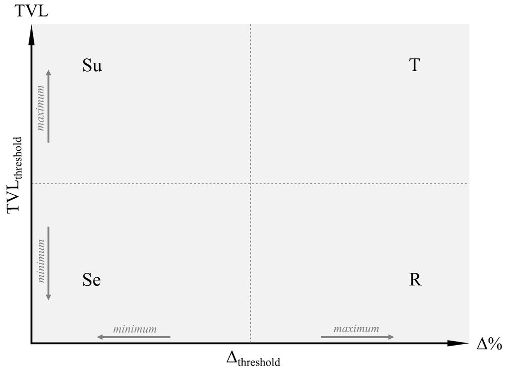

**Figure 1:** Schematic representation used for sweetpotato genotypes classification.

## Virus load and yield data

The dataset for this demostration consist of two evaluations of virus load (`_EV1` and `_EV2` measurement at 48 and 79 days after transplanting, respectively) and total yield (`bytha`). Regarding the virus load variable, we evaluate the qPCR Relative Expression Ratio (qPCR_RER) for 3 virus: sweet potato feathery mottle virus (SPFMV, `SPFMV_EV1` and `SPFMV_EV2`), sweet potato chlorotic stunt virus (SPCVS, `SPCVS_EV1` and `SPCVS_EV2`) and sweet potato leaf curl virus (SPLCV, `SPLCV_EV1` and `SPLCV_EV2`). Raw data can be download [here](https://doi.org/10.21223/ZCIWUL). Let’s see the data with the R chunk code below:

```r
df <- read.csv("virus-load_&_yield_data.csv")
#table(df$genotype, df$trt)
str(df)
```

```
## 'data.frame':    108 obs. of  10 variables:
##  $ genotype : chr  "Arne" "Arne" "Arne" "Beauregard" ...
##  $ rep      : chr  "R1" "R2" "R3" "R1" ...
##  $ trt      : chr  "GI" "GI" "GI" "GI" ...
##  $ SPFMV_EV1: num  105758 159805 419497 777726 391411 ...
##  $ SPCSV_EV1: num  506895 413490 442076 619289 2220487 ...
##  $ SPLCV_EV1: num  30037 90530 83209 12840 8198 ...
##  $ SPFMV_EV2: num  80358 301043 507270 3784890 1297839 ...
##  $ SPCSV_EV2: num  1572664 538377 1096924 2760434 2780542 ...
##  $ SPLCV_EV2: num  79667 183477 134910 216961 95820 ...
##  $ bytha    : num  27.4 46.8 16 22 18.3 ...
```

Note that there are 108 observations: 12 genotypes (`genotype`) $\times$ 3 repetitions (`rep`) $\times$ 3 treatments (`trt`). To calculate total yield reduction (Δ%, `YR` in the R code), we considered the mean values per genotype of the control treatment (**CTL**) and compare them against the other treatments (**GI** - “Grafted-Infected” and **NI** - “Natural Infected”). The 2 virus load evaluations were averaged by virus, and then the arithmetic sum of these was considered as Total Virus Load (`TVL`). Let’s run the R chunk code below for that:

```r
# loading libraries
library(dplyr)

# total yield mean values per genotype for plants under control treatment
smr <- df[df$trt=="CTL",] %>%
  group_by(genotype) %>%
  summarise_at(c("bytha"), mean, rm.na=TRUE)

# new column for the control values
df$bytha_CTL <- rep(rep(smr$bytha, each = 3), 3)

# Percentage of yield reduction (Δ%) computation
df$YR <- (df$bytha - df$bytha_CTL)/df$bytha_CTL*100

# Total Virus Load (TVL) computation
## average of the two evaluations
df$SPFMV <- (df$SPFMV_EV1 + df$SPFMV_EV2)/2
df$SPCSV <- (df$SPCSV_EV1 + df$SPCSV_EV2)/2
df$SPLCV <- (df$SPLCV_EV1 + df$SPLCV_EV2)/2

## arithmetic sum of each kind of virus load
df$TVL <- df$SPFMV + df$SPCSV + df$SPLCV
```

## Clasification criteria

A function (`virus_class`) based on TVL and Δ% (`YR` in the R code) were made. Thus, four categories corresponding to each quadrants of the scatter plot showed in Fig. 1 was defined as follow:

- Susceptible: Δ% $\le$ `-20` & TVL $\ge$ `TVL_threshold` (upper left quadrant).
- Sensitive: Δ% $\le$ `-20` & TVL $\le$ `TVL_threshold` (lower left quadrant).
- Tolerant: Δ% $\ge$ `-20` & TVL $\ge$ `TVL_threshold` (upper right quadrant).
- Resistant: Δ% $\ge$ `-20` & TVL $\le$ `TVL_threshold` (lower right quadrant).

`TVL_threshold` was considered as the midpoint of the range of values (for GI treatment) on the y-axis , and a value of -20% was used as YR threshold (`YR_threshold`). Let’s run the R chunk code below for that:

```r
# Function for genotypes classification based on TVL and YR
virus_class <- function(id, TVL, YR, data, TVL_threshold = NULL, YR_threshold = -20){

  TVL = data$TVL
  YR = data$YR
  ID = data$id
  class = vector()

  # Threshold value for TVL
  if(is.null(TVL_threshold)) {
    LR = log(range(TVL))
    TVL_threshold = exp(LR[1] + (LR[2] - LR[1])/2)
  }

  for(i in 1:nrow(data)){

  # Classification criteria
    if(YR[i] <= YR_threshold & TVL[i] >= TVL_threshold){
      class[i] = "Susceptible"
    } else if (YR[i] <= YR_threshold & TVL[i] <= TVL_threshold){
      class[i] = "Sensitive"
    } else if (YR[i] >= YR_threshold & TVL[i] >= TVL_threshold){
      class[i] = "Tolerant"
    } else if (YR[i] >= YR_threshold & TVL[i] <= TVL_threshold){
      class[i] = "Resistant"
    }
  }

  dfr <- data.frame(ID, TVL, YR, class)

  return(out = list("out" = dfr, "TVL_threshold" = TVL_threshold))
}
```

Let’s run the `virus_class` function for **GI**:

```r
df$id <- paste0(df$genotype, " + ", df$rep)
(vc_GI <- virus_class("id", "TVL", "YR", data = df[df$trt == "GI",]))
```

```
## $out
##                 ID          TVL          YR       class
## 1        Arne + R1 1.187690e+06 -67.5708384 Susceptible
## 2        Arne + R2 8.433605e+05 -44.5838357 Susceptible
## 3        Arne + R3 1.341943e+06 -80.9893432 Susceptible
## 4  Beauregard + R1 4.086070e+06 -65.3295213 Susceptible
## 5  Beauregard + R2 3.397149e+06 -71.2361471 Susceptible
## 6  Beauregard + R3 1.377947e+07 -81.5550578 Susceptible
## 7    Benjamin + R1 8.605235e+06 -40.9972057 Susceptible
## 8    Benjamin + R2 9.438455e+05 -44.4725812 Susceptible
## 9    Benjamin + R3 2.779497e+06 -44.5424380 Susceptible
## 10      Dagga + R1 4.634649e+06 -44.3992162 Susceptible
## 11      Dagga + R2 3.675008e+06 -57.3099046 Susceptible
## 12      Dagga + R3 5.732970e+07 -68.8136022 Susceptible
## 13    Ejumula + R1 2.194336e+05 -14.9553786    Tolerant
```

[output cut: 26 more lines]

Note that we also can run the `virus_class` function for the other treatments. Let’s run the R chunk code below for **NI** treatment:

```r
# TVL_threshold value determined for GI (vc_GI$TVL_threshold) is used for NI
TVL_threshold <- vc_GI$TVL_threshold
(vc_NI <- virus_class("id", "TVL", "YR", data = df[df$trt == "NI",], TVL_threshold))
```

```
## $out
##                 ID          TVL         YR       class
## 1        Arne + R1 8.738479e+04 -52.762607 Susceptible
## 2        Arne + R2 7.535730e+02 -36.950316   Sensitive
## 3        Arne + R3 5.748279e+03 -19.921182   Resistant
## 4  Beauregard + R1 2.559590e+05 -37.449894 Susceptible
## 5  Beauregard + R2 3.837734e+06 -39.174133 Susceptible
## 6  Beauregard + R3 1.887294e+01  -4.026173   Resistant
## 7    Benjamin + R1 4.444196e+05  -2.663290    Tolerant
## 8    Benjamin + R2 2.085212e+06 -22.668530 Susceptible
## 9    Benjamin + R3 2.250120e+03 -34.526720   Sensitive
## 10      Dagga + R1 1.048170e+04 -30.383667   Sensitive
## 11      Dagga + R2 2.032398e+03 -44.314519   Sensitive
## 12      Dagga + R3 1.091137e+05 -28.342077 Susceptible
## 13    Ejumula + R1 1.419467e+01 -35.514826   Sensitive
```

[output cut: 26 more lines]

and now for **CTL** treatment:

```r
# TVL_threshold value determined for GI (vc_GI$TVL_threshold) is used for CTL
TVL_threshold <- vc_GI$TVL_threshold
(vc_CTL <- virus_class("id", "TVL", "YR", data = df[df$trt == "CTL",], TVL_threshold))
```

```
## $out
##                 ID          TVL          YR       class
## 1        Arne + R1  18948.18100   2.3210866   Resistant
## 2        Arne + R2  19712.26464   6.5687283   Resistant
## 3        Arne + R3   1467.04844  -8.8898149   Resistant
## 4  Beauregard + R1 411484.99335   3.5074275    Tolerant
## 5  Beauregard + R2     75.41165 -24.5490450   Sensitive
## 6  Beauregard + R3 453363.09382  21.0416175    Tolerant
## 7    Benjamin + R1  12349.84624  24.2752358   Resistant
## 8    Benjamin + R2 259532.63850 -25.1571778 Susceptible
## 9    Benjamin + R3   2725.10352   0.8819420   Resistant
## 10      Dagga + R1    840.04547   7.9893812   Resistant
## 11      Dagga + R2   4313.39409 -12.6224638   Resistant
## 12      Dagga + R3  43029.98823   4.6330826   Resistant
## 13    Ejumula + R1     16.83689   0.2862809   Resistant
```

[output cut: 26 more lines]

Now let’s save the classification results in `df$class`:

```r
df$class <- NA
df$class[df$trt == "GI"] <- vc_GI$out$class
df$class[df$trt == "NI"] <- vc_NI$out$class
df$class[df$trt == "CTL"] <- vc_CTL$out$class

write.csv(df, "out_data.csv")

table(df$trt,df$class)
```

```
##
##       Resistant Sensitive Susceptible Tolerant
##   CTL        30         3           1        2
##   GI          7         2          19        8
##   NI          9        21           5        1
```

## Schematic representation for Grafted-Infected plants

For the purpose of this demonstration, we only considered plants under GI because is there where they can express their maximum response capacity to virus infection, and so we can know their “real” resistance and tolerance capacity. Let’s see a schematic representation of this classification for Grafted-Infected plants:

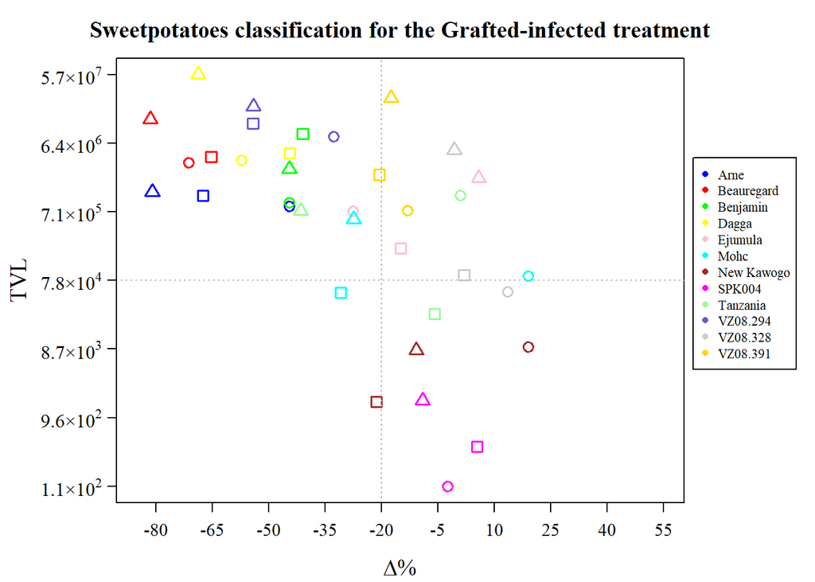

```r
xpch<-rep(0:2, 12)
xcolor<-c("blue", "red", "green", "yellow", "pink", "cyan",
          "brown", "magenta", "palegreen", "slateblue", "gray80", "gold")
xcol=rep(xcolor,each=3)

par(family = "serif", mar = c(3.4,5,2.5,5.6))

# TVL and YR data
x=vc_GI$out$YR
y=vc_GI$out$TVL

# TVL and YR tresholds
ymean=vc_GI$TVL_threshold
xmean=-20

plot(x, y, pch = xpch, col = xcol, axes = FALSE, lwd = 1.5, cex = 1.2,
     log = "y", xlab = "", ylab = "", las = 1, xlim = c(-85, 55))
title("Sweetpotatoes classification for the Grafted-infected treatment")

box()
abline(h = ymean,v = xmean, lty=3, col="gray70")

# x-axis
axis(side = 1, at = seq(-80,55,by=15), tck = -0.02, mgp = c(2,0.6,0), las = 1,  cex.axis = 0.95)
mtext(side = 1, bquote(Delta*"%"), line = 2.3, cex = 1.2)

# y-axis
yat = exp(seq(log(range(y)[1]), log(range(y)[2]), length = 7))
axis(side=2, at=yat, tck=-0.02, mgp=c(2,0.6,0), las=1, labels = expression(1.1*"\u00D7"*10^2,
                                                                           9.6*"\u00D7"*10^2,
                                                                           8.7*"\u00D7"*10^3,
                                                                           7.8*"\u00D7"*10^4,
                                                                           7.1*"\u00D7"*10^5,
                                                                           6.4*"\u00D7"*10^6,
                                                                           5.7*"\u00D7"*10^7))
mtext(side = 2, bquote("TVL"), line = 3.7, cex = 1.2)

# legend
par(xpd = TRUE)
legend(x = 63, y = 4005000, legend = unique(df$geno), col = xcolor, cex = 0.7, pch = c(rep(16,12)))
```